# Data Analysis Project

Yixin Wang, Yaoling Wang, Tiantian Zhang

8/3/2019

#### Group Members

| Name | NetID |
| --- | --- |
| Yixin Wang | yixinw2 |
| Yaoling Wang | yaoling2 |
| Tiantian Zhang | tz8 |

## Introduction

#### Project Title

**Analysis of Property Price in New York**

The data includes 1734 random samples which were taken from full Saratoga Housing Data (De Veaux).

#### Dataset

A snippet. Here are the first 10 columns of the dataset inclusing response variable “price”.

```r
library(readr)
house = read.csv("housing-prices-ge19.csv")
knitr::kable(head(house)[,1:10])
```

| Price | Lot.Size | Waterfront | Age | Land.Value | New.Construct | Central.Air | Fuel.Type | Heat.Type | Sewer.Type |
| --- | --- | --- | --- | --- | --- | --- | --- | --- | --- |
| 132500 | 0.09 | 0 | 42 | 50000 | 0 | 0 | Electric | Electric | Private |
| 181115 | 0.92 | 0 | 0 | 22300 | 0 | 0 | Gas | Hot Water | Private |
| 109000 | 0.19 | 0 | 133 | 7300 | 0 | 0 | Gas | Hot Water | Public |
| 155000 | 0.41 | 0 | 13 | 18700 | 0 | 0 | Gas | Hot Air | Private |
| 86060 | 0.11 | 0 | 0 | 15000 | 1 | 1 | Gas | Hot Air | Public |
| 120000 | 0.68 | 0 | 31 | 14000 | 0 | 0 | Gas | Hot Air | Private |

#### Dataset Description

The dataset has 1,734 observations. It includes below information of the properties in New York area:

- `Price` - The housing price
- `Lot.Size` - The lot size
- `Living.Area`
- `Land.Value`
- `Age` - The number of years the property has been built
- `New.Construct` - A dummy variable that takes the value 1 if the property is newly constructed
- `Pct.College`
- `Fuel.Type` - Electric, gas or oil
- `Heat.Type` - Electric, hot water, or hot air
- `Sewer.Type` - Private or public
- `Central.Air` - A dummy variable that takes the value 1 if the property has central air conditioner
- `Waterfront` - A dummy variable that takes the value 1 if there is a waterfront in the property
- `Fireplaces` - The number of fireplaces
- `Bedrooms` - The number of bedrooms
- `Bathrooms` - The number of bathrooms
- `Rooms` - The number of rooms
- `Test`

We are attempting to fit a model with `Price` as the response and the remaining variables as predictors.

#### Source

- Data: `housing-prices.csv`
- Website: https://dasl.datadescription.com/datafile/housing-prices-ge19/

#### Interest in Topic

- Our team chooses housing prices in Saratoga because we all have a deep interest in real estate, especially the pricing of a piece of real property.
- Generally, we link the housing price with living area, but we believe that there must be properties besides living area that influence the housing price. To be specific, we would like to know how these properties interact and play a role in determining the housing prices.
- Based on the model we build, we would like to figure out what properties influence the housing price most and what properties should be ignored or less concerned about when we determine a housing price.
- Furthermore, using our model, we could have a round estimate of a housing price and evaluate whether the housing price provided by a third-party is overestimated or not.

#### Goal of this model

- Our group aims to create a model that helps to predict the housing price in New York.

## Methods

```r
# Read the data
library(readr)
house <- read_csv("housing-prices-ge19.csv")
View(house)

# Remove missing data
house = subset(house, house$Fuel.Type != "Unknown/Other")
house = subset(house, house$Fuel.Type != "None")
house = subset(house, house$Heat.Type != "None")
house = subset(house, house$Sewer.Type != "None/Unknown")

# Change variables from character to factor
house$Fuel.Type = as.factor(house$Fuel.Type)
house$Heat.Type = as.factor(house$Heat.Type)
house$Sewer.Type = as.factor(house$Sewer.Type)

# Check final structure of data
str(house)
```

```
## Classes 'tbl_df', 'tbl' and 'data.frame':    1716 obs. of  17 variables:
##  $ Price        : num  132500 181115 109000 155000 86060 ...
##  $ Lot.Size     : num  0.09 0.92 0.19 0.41 0.11 0.68 0.4 1.21 0.83 2.29 ...
##  $ Waterfront   : num  0 0 0 0 0 0 0 0 0 0 ...
##  $ Age          : num  42 0 133 13 0 31 33 23 36 123 ...
##  $ Land.Value   : num  50000 22300 7300 18700 15000 14000 23300 14600 22200 12600 ...
##  $ New.Construct: num  0 0 0 0 1 0 0 0 0 0 ...
##  $ Central.Air  : num  0 0 0 0 1 0 0 0 0 0 ...
##  $ Fuel.Type    : Factor w/ 3 levels "Electric","Gas",..: 1 2 2 2 2 2 3 3 1 3 ...
##  $ Heat.Type    : Factor w/ 3 levels "Electric","Hot Air",..: 1 3 3 2 2 2 3 2 1 2 ...
##  $ Sewer.Type   : Factor w/ 2 levels "Private","Public": 1 1 2 1 2 1 1 1 1 1 ...
##  $ Living.Area  : num  906 1953 1944 1944 840 ...
##  $ Pct.College  : num  35 51 51 51 51 22 51 35 51 51 ...
##  $ Bedrooms     : num  2 3 4 3 2 4 4 4 3 7 ...
##  $ Fireplaces   : num  1 0 1 1 0 1 1 1 0 0 ...
##  $ Bathrooms    : num  1 2.5 1 1.5 1 1 1.5 1.5 1.5 1 ...
##  $ Rooms        : num  5 6 8 5 3 8 8 9 8 12 ...
##  $ Test         : num  0 1 1 0 0 1 0 0 0 0 ...
```

$\quad$ Before we attempt to fit the models that predict `price`, four predictor variables catch our eyes: `Living.Area`, `Rooms`, `Bedrooms` and `Bathrooms`. We suspect the living area of a property is somewhat correlated to its number of rooms, including bedrooms and bathrooms. To test our guess, we run the following code:

```r
living_area_mod = lm(Living.Area ~ Rooms + Bedrooms + Bathrooms, data = house)
summary(living_area_mod)$r.squared
```

```
## [1] 0.7179639
```

$\quad$ Here we see that `Rooms`, `Bedrooms` and `Bathrooms` explain 71.80% of the variation in `Living.Area`. In addition, as the `Rooms` variable is partly consists of `Bedrooms` and `Bathrooms`, we decided to remove `Living.Area` and `Rooms`.

$\quad$ Furthermore, the `New.Construct` variable is also correlated to the `Age` variable, as `New.Construct` indicates the properties whose `Age` equals to 0. Therefore, we decided to remove the `New.Construct` predictor as well.

```r
house_data = subset(house, select = -c(Living.Area, Rooms, New.Construct))
```

$\quad$ Now, we check the multicollinearity issue again.

```r
round(cor(subset(house_data, select = -c(Fuel.Type, Heat.Type, Sewer.Type))), 2)
```

```
##             Price Lot.Size Waterfront   Age Land.Value Central.Air
## Price        1.00     0.16       0.16 -0.19       0.58        0.33
## Lot.Size     0.16     1.00       0.00 -0.01       0.06       -0.01
## Waterfront   0.16     0.00       1.00  0.02       0.12       -0.02
## Age         -0.19    -0.01       0.02  1.00      -0.02       -0.28
## Land.Value   0.58     0.06       0.12 -0.02       1.00        0.24
## Central.Air  0.33    -0.01      -0.02 -0.28       0.24        1.00
## Pct.College  0.20    -0.03      -0.09 -0.04       0.23        0.24
## Bedrooms     0.40     0.11      -0.07  0.03       0.21        0.08
## Fireplaces   0.38     0.09      -0.01 -0.17       0.22        0.28
## Bathrooms    0.60     0.08       0.00 -0.36       0.30        0.35
## Test         0.01    -0.01      -0.01 -0.02      -0.04        0.01
##             Pct.College Bedrooms Fireplaces Bathrooms  Test
## Price              0.20     0.40       0.38      0.60  0.01
## Lot.Size          -0.03     0.11       0.09      0.08 -0.01
## Waterfront        -0.09    -0.07      -0.01      0.00 -0.01
## Age               -0.04     0.03      -0.17     -0.36 -0.02
## Land.Value         0.23     0.21       0.22      0.30 -0.04
## Central.Air        0.24     0.08       0.28      0.35  0.01
## Pct.College        1.00     0.16       0.25      0.18 -0.01
## Bedrooms           0.16     1.00       0.28      0.46 -0.03
## Fireplaces         0.25     0.28       1.00      0.44  0.00
## Bathrooms          0.18     0.46       0.44      1.00 -0.01
## Test              -0.01    -0.03       0.00     -0.01  1.00
```

$\quad$ From the matrix above, we see no obvious collinearity.

$\quad$ Then we start searching proper models to predict the housing price in New York, using the backwards selection via AIC and BIC. We set three models for the starts of the research:

- `full_add_mod`: An additive model that considers all available predictors
- `full_big_mod`: A model that considers all available predictors as well as their polynomial and logarithmic transformations
- `full_log_mod`: A model that uses logarithmic transformation of the response and considers all available predictors as well as their polynomial and logarithmic transformations

$\quad$ After finding the “best” models with the help of the backwards research, we extract the unusual observations that has a large effect on the regression and refit the models.

```r
# Extract influential points
get_influential = function(model) {
  which(cooks.distance(model) > 4 / length(cooks.distance(model)))
}


full_add_mod = lm(Price ~ ., data = house_data)

# backward AIC using full_add_mod as the start
back_aic_add_mod = step(full_add_mod, direction = "backward", trace = 0)
unusual = get_influential(back_aic_add_mod)
house_data_aic_add = house_data[-unusual,]
back_aic_add_mod = lm(formula = back_aic_add_mod, data = house_data_aic_add)

# backward BIC using full_add_mod as the start
back_bic_add_mod = step(full_add_mod, direction = "backward", k = log(length(resid(full_add_mod))), trace = 0)
unusual = get_influential(back_bic_add_mod)
house_data_bic_add = house_data[-unusual,]
back_bic_add_mod = lm(formula = back_bic_add_mod, data = house_data_bic_add)


full_big_mod = lm(Price ~ . + I(Lot.Size ^ 2) + I(Age ^ 2) + I(Land.Value ^ 2) + I(Pct.College) + log(Land.Value) + log(Pct.College), data = house_data)

# backward AIC using full_big_mod as the start
back_aic_big_mod = step(full_big_mod, direction = "backward", trace = 0)
unusual = get_influential(back_aic_big_mod)
house_data_aic_big = house_data[-unusual,]
back_aic_big_mod = lm(formula = back_aic_big_mod, data = house_data_aic_big)

# backward BIC using full_big_mod as the start
back_bic_big_mod = step(full_big_mod, direction = "backward", k = log(length(resid(full_add_mod))), trace = 0)
unusual = get_influential(back_bic_big_mod)
house_data_bic_big = house_data[-unusual,]
back_bic_big_mod = lm(formula = back_bic_big_mod, data = house_data_bic_big)


full_log_mod = lm(log(Price) ~ . + I(Lot.Size ^ 2) + I(Age ^ 2) + I(Land.Value ^ 2) + I(Pct.College) + log(Land.Value) + log(Pct.College), data = house_data)

# backward AIC using full_log_mod as the start
back_aic_log_mod = step(full_log_mod, direction = "backward", trace = 0)
unusual = get_influential(back_aic_log_mod)
house_data_aic_log = house_data[-unusual,]
back_aic_log_mod = lm(formula = back_aic_log_mod, data = house_data_aic_log)

# backward BIC using full_log_mod as the start
back_bic_log_mod = step(full_log_mod, direction = "backward", k = log(length(resid(full_add_mod))), trace = 0)
unusual = get_influential(back_bic_log_mod)
house_data_bic_log = house_data[-unusual,]
back_bic_log_mod = lm(formula = back_bic_log_mod, data = house_data_bic_log)
```

## Results

$\quad$ To select the most suitable model among the results of backwards research, we first check the four basic assumptions of linear regression: **Linearity**, **Independence**, **Normality** and **Equal Variance**. We also calculate their **adjusted $R^2$** and **LOOCV RMSE** as well, as they both not only assess the quality of fit but also consider the size of the model. Due to our prediction purpose, we focus more on LOOCV RMSE as it implicitly penalizes larger models.

```r
library(lmtest)
library(faraway)

# Check normality assumption
get_sw_decision = function(model, alpha = 0.05){
  decide = unname(shapiro.test(resid(model))$p.value < alpha)
  ifelse(decide, "Reject", "Fail to Reject")
}

# Check equal variance assumption
get_bp_decision = function(model, alpha = 0.05){
  decide = unname(bptest(model)$p.value < alpha)
  ifelse(decide, "Reject", "Fail to Reject")
}

# Calculate adjusted r squared
get_adj_r2 = function(model) {
  summary(model)$adj.r.squared
}

# Calculate LOOCV RMSE
get_loocv_rmse = function(model) {
  sqrt(mean((resid(model) / (1 - hatvalues(model))) ^ 2))
}

# Calculate number of parameters
get_num_params = function(model) {
  length(coef(model))
}

# Calculate the number of vif larger than 5
get_big_vif = function(model) {
  sum(vif(model) > 5)
}

select_mod = data.frame(sw_decision = c(get_sw_decision(back_aic_add_mod),
                                            get_sw_decision(back_bic_add_mod),
                                            get_sw_decision(back_aic_big_mod),
                                            get_sw_decision(back_bic_big_mod),
                                            get_sw_decision(back_aic_log_mod),
                                            get_sw_decision(back_bic_log_mod)),
                            bp_decision = c(get_bp_decision(back_aic_add_mod),
                                            get_bp_decision(back_bic_add_mod),
                                            get_bp_decision(back_aic_big_mod),
                                            get_bp_decision(back_bic_big_mod),
                                            get_sw_decision(back_aic_log_mod),
                                            get_sw_decision(back_bic_log_mod)),
                            loocv_rmse = c(get_loocv_rmse(back_aic_add_mod),
                                           get_loocv_rmse(back_bic_add_mod),
                                           get_loocv_rmse(back_aic_big_mod),
                                           get_loocv_rmse(back_bic_big_mod),
                                           get_loocv_rmse(back_aic_log_mod),
                                           get_loocv_rmse(back_bic_log_mod)),
                            adj_r2 = c(get_adj_r2(back_aic_add_mod),
                                       get_adj_r2(back_bic_add_mod),
                                       get_adj_r2(back_aic_big_mod),
                                       get_adj_r2(back_bic_big_mod),
                                       get_adj_r2(back_aic_log_mod),
                                       get_adj_r2(back_bic_log_mod)),
                            num_params = c(get_num_params(back_aic_add_mod),
                                           get_num_params(back_bic_add_mod),
                                           get_num_params(back_aic_big_mod),
                                           get_num_params(back_bic_big_mod),
                                           get_num_params(back_aic_log_mod),
                                           get_num_params(back_bic_log_mod)),
                            big_vif = c(get_big_vif(back_aic_add_mod),
                                        get_big_vif(back_bic_add_mod),
                                        get_big_vif(back_aic_big_mod),
                                        get_big_vif(back_bic_big_mod),
                                        get_big_vif(back_aic_log_mod),
                                        get_big_vif(back_bic_log_mod)),
                            row.names = c("back_aic_add_mod",
                                          "back_bic_add_mod",
                                          "back_aic_big_mod",
                                          "back_bic_big_mod",
                                          "back_aic_log_mod",
                                          "back_bic_log_mod"))

kable(select_mod)
```

|  | sw_decision | bp_decision | loocv_rmse | adj_r2 | num_params | big_vif |
| --- | --- | --- | --- | --- | --- | --- |
| back_aic_add_mod | Reject | Reject | 4.860981e+04 | 0.6435537 | 11 | 0 |
| back_bic_add_mod | Reject | Reject | 4.789128e+04 | 0.6418449 | 8 | 0 |
| back_aic_big_mod | Reject | Reject | 4.864767e+04 | 0.6414100 | 15 | 3 |
| back_bic_big_mod | Reject | Reject | 4.720735e+04 | 0.6462071 | 11 | 3 |
| back_aic_log_mod | Reject | Reject | 2.372523e-01 | 0.6515627 | 15 | 7 |
| back_bic_log_mod | Fail to Reject | Fail to Reject | 2.413677e-01 | 0.6433436 | 12 | 6 |

$\quad$ To double-check whether it satisfies all the assumptions of regression, we also draw its fitted vs residuals plot and normal Q-Q plot.

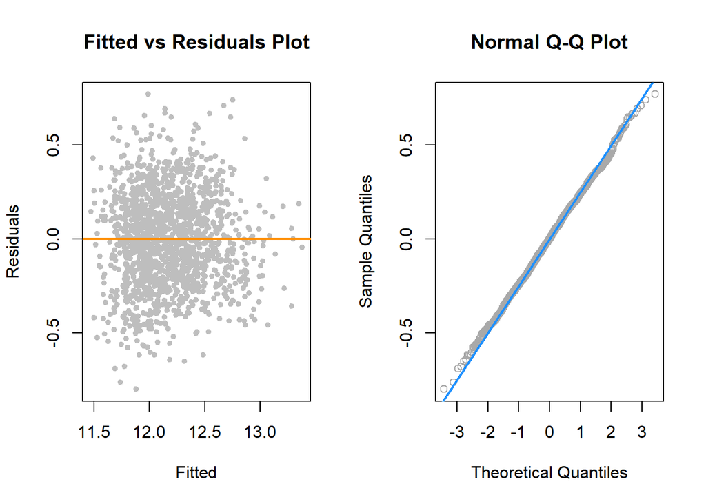

```r
par(mfrow = c(1, 2))

plot(fitted(back_bic_log_mod), resid(back_bic_log_mod), col = "grey", pch = 20, xlab = "Fitted", ylab = "Residuals", main = "Fitted vs Residuals Plot")
abline(h = 0, col = "darkorange", lwd = 2)

qqnorm(resid(back_bic_log_mod), main = "Normal Q-Q Plot", col = "darkgrey")
qqline(resid(back_bic_log_mod), col = "dodgerblue", lwd = 2)
```

$\quad$ As we can see from the charts, the points in the fitted vs residuals plot are roughly centered at 0 with basically equal spreads. And the points in Q-Q plot strictly follow a straight line as well. Therefore, the model, `back_bic_log_mod`, does not violates any assumptions and becomes our final choise of model.

```r
formula(back_bic_log_mod)
```

```
## log(Price) ~ Lot.Size + Waterfront + Age + Land.Value + Central.Air +
##     Bedrooms + Fireplaces + Bathrooms + I(Lot.Size^2) + I(Age^2) +
##     I(Land.Value^2)
```

**The best model:** `back_bic_log_mod`

$$log(\text{Price}) = 11.26 + 0.18 * \text{Lot.Size} + 0.68 * \text{Waterfront} + 0 * \text{Age} + 0 * \text{Land.Value} + 0.07 * \text{Central.Air} + 0.1 * \text{Bedrooms} + 0.06 * \text{Fireplaces} + 0.18 * \text{Bathrooms} + -0.02 * \text{Lot.Size} ^ 2 + 0 * \text{Age} ^ 2 + 0 * \text{Land.Value} ^ 2$$